# BS2280 – Econometrics I

# Homework 3: Interpretation of coefficients and properties of OLS

## Question 1

The output shows the result of regressing the weight of the respondent in 2004, measured in pounds, on his or her height, measured in inches. Provide an interpretation of the coefficients. Does this model provide a good fit?

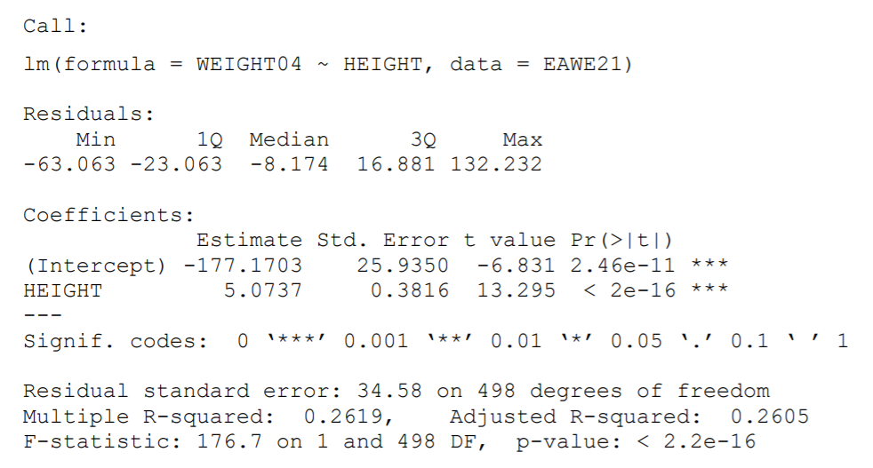

Writing out the estimated regression model will be helpful.

- Interpretation of the HEIGHT coefficient: Literally the regression implies that, for extra 1 inch(es) of height, an individual tends to weigh an extra 5.0737 pounds.
- Interpretation of the constant: The intercept, which literally suggests that an individual with no height would weigh -177.1703 pounds, has no meaning.
- The overall fit of the model ($R^2$) is 0.2619 which is rather low, as only 26% of the variation in weight can be explained by the variation in height

## Question 2

Do earnings depend on education? Use the output table below to give an interpretation of the coefficients. Comment also on $R^2$.

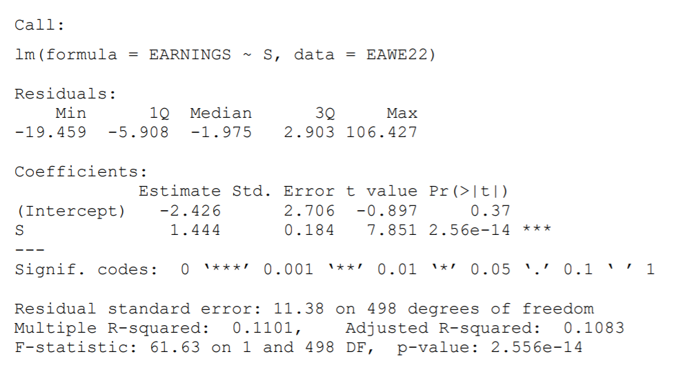

Of course earnings depend (partly) on education.

Writing out the estimated regression model will be helpful.

- Interpretation of the education coefficient: Literally the regression implies that, for extra 1 year(s) of education increases hourly earnings by $1.444.
- Interpretation of the constant: literally implies that an individual with no years of schooling would earn $-2.426 per hour. There are two ways out of this nonsense.
- One is to say that the fitted relationship can claim to be valid only for the range of values of S in the data set (7–20 in this one) and nothing can be inferred for values outside this range.
- The other is to say that the relationship may be nonlinear and the negative intercept is an artefact caused by forcing a linear relationship on the observations.
- The overall fit of the model ($R^2$) is 0.1101, which is rather low, as only 11% of the variation in earnings can be explained with the variation in years of schooling.

## Question 3

What are the 6 main assumptions of OLS? For each assumption explain the implications if it does not hold.

**Assumption 1**: Model is linear in parameters and correctly specified.

**Assumption 2**: There is some variation in the X variable.

**Assumption 3**: Disturbance term has zero expectation.

**Assumption 4**: Disturbance term is homoscedastic.

**Assumption 5**: Values of disturbance term have independent distributions.

**Assumption 6**: The disturbance term has a normal distribution.

**Assumption 1**: Model is linear in parameters and correctly specified.

If assumption 1 does not hold, poor fit of model

**Assumption 2**: There is some variation in the X variable.

If assumption 2 does not hold, betas cannot be estimated

**Assumption 3**: Disturbance term has zero expectation.

If assumption 3 does not hold, interpretation of intercept will change

**Assumption 4**: Disturbance term is homoscedastic.

If assumption 4 does not hold, inefficient estimates/ unreliable results

**Assumption 5**: Values of disturbance term have independent distributions.

If assumption 5 does not hold, inefficient estimates/ unreliable results

**Assumption 6**: The disturbance term has a normal distribution.

If assumption 6 does not hold, cannot undertake standard hypothesis tests

## Question 4

The OLS estimator is BLUE. Explain what BLUE stands for and why OLS is referred to BLUE.

BLUE stands for Best Linear Unbiased Estimator

The Gauss-Markov Theorem states that provided the assumptions hold, OLS estimators will have the lowest variance amongst all possible estimators.

An estimator with low variance means it comes from a sampling distribution where most of the values are concentrated around the true but unknown population value of the characteristic it is estimating.

## Question 5

Referring to the equation below, explain what factors determine the variance of $\hat{\beta}_{2}$. Furthermore, use this formula to explain why OLS will be the most efficient estimator.

$$\begin{equation*}
\sigma^2_{\hat{\beta}_{2}}=\frac{\sigma^2_{u_{i}}}{nMSD(X)}
\end{equation*}$$

Three factors will determine variance of $\hat{\beta}_{2}$:

Refer to the Lecture 3, Part 2 slides for assistance.

1. Number of observations ($n$): The larger $n$, the smaller $\sigma^2_{\hat{\beta}_{2}}$
2. Variance of residuals: Larger residuals reduce precision of estimates
3. Larger MSD($X$) leads to smaller $\sigma^2_{\hat{\beta}_{2}}$: Low variations in MSD($X$) means low variations in $X_{i}\rightarrow$ more variations from $u_{i}\rightarrow$ higher variance (lower precision) in $\sigma^2_{\hat{\beta}_{2}}$

OLS is the estimator that minimises the size of the residuals. Therefore it will have a smaller $\sigma^2_{\hat{\beta}_{2}}$ than any other estimator.